# Explicacion de dina_analysis.R

```r
# Data Simulation ---------------------------------------------------------

# function in Scripts/data_sim_function.R
source("Dina_simulation_function.R")
```

La funcion `source` permite ejecutar un script por completo que se encuentre en el mismo directorio de trabajo (es por eso que no se especifica la ruta completa, solo el nombre del script.). Al ejecutar un script dentro de otro script lo que permite es que se almacenen las variables que se encontraban en `Dina_simulation_function.R` (en ese script se encuentra la funcion que simula los datos) sin necesidad de agregarlas al inicio.

```r
# Q- matrix
Q <- matrix(c(1,0,0,0,1,0,0,0,1,1,0,0,1,1,0,0,1,1,0,0,1,1,0,0,1,1,0,0,1,1,0,0,0,
              1,0,0,0,1,0,1,1,1,1,1,1,1,1,1,1,1,1,1,1,1,1,1,1,1,1,1,0,0,1,0,1,1,
              1,1,0,1,0,1,1,0,0,1,1,0,0,0),
            ncol = 4, nrow = 20, byrow = TRUE)
Q
```

```
##       [,1] [,2] [,3] [,4]
##  [1,]    1    0    0    0
##  [2,]    1    0    0    0
##  [3,]    1    1    0    0
##  [4,]    1    1    0    0
##  [5,]    1    1    0    0
##  [6,]    1    1    0    0
##  [7,]    1    1    0    0
##  [8,]    1    1    0    0
##  [9,]    0    1    0    0
## [10,]    0    1    0    1
## [11,]    1    1    1    1
## [12,]    1    1    1    1
## [13,]    1    1    1    1
## [14,]    1    1    1    1
## [15,]    1    1    1    1
## [16,]    0    0    1    0
## [17,]    1    1    1    1
## [18,]    0    1    0    1
## [19,]    1    0    0    1
## [20,]    1    0    0    0
```

Luego se almacena los datos de la matriz Q (20x4) en el objeto `Q`.

```r
dina <- dina_data_sim(slip_guess_min = .1, slip_guess_max = .3, Q = Q)
```

Con la funcion `dina_data_sim()` (que proviene del script `Dina_simulation_function.R`) se generan los datos con los limites de `slip` y `guess` entre 0.1 y 0.3, tambien es necesario ingresar la matriz Q para la simulacion, y se guarda la simulacion en el objeto `dina` (La lista contien los objetos sim_dina, alphas, slip_par, guess_par).

Paquetes necesarios para el analisis:

- MplusAutomation: paquete que permite usar Mplus con R.
- dplyr: paquete de manejo de datos.
- ggplot2: paquete para visualizar los datos.
- extrafont: paquete que permite cambiar de fuente en los graficos ggplot2.
- latex2exp: permite usar latex en los ejes de los graficos ggplot2 (No funciona con las leyendas).

```r
# Preparing data
prepareMplusData(dina$sim_dina, "../Data/lta_dina.dat")
```

Esta funcion *exporta* la simulacion a un archivo `lta_dina.dat` en formato `.dat`.

```r
# Model
runModels("C:/Users/Usuario/Dropbox/Dina/mplus", showOutput = TRUE)
output2 <- readModels("C:/Users/Usuario/Dropbox/Dina/mplus/lta_dina.out")
```

Estas funciones permiten correr el modelo desde R, usando Mplus como subproceso y con `readModels` almacena el output como un solo objeto de R (formato lista).

```r
# Savedata analysis
savedata <- as.tbl(output2$savedata)
savedata_prof <- savedata %>%
  select(C1:C8) %>%
  mutate(C1 = ifelse(C1 == 2, 1, 0), # 2 es dominio y 1 es no dominio
         C2 = ifelse(C2 == 2, 1, 0),
         C3 = ifelse(C3 == 2, 1, 0),
         C4 = ifelse(C4 == 2, 1, 0),
         C5 = ifelse(C5 == 2, 1, 0),
         C6 = ifelse(C6 == 2, 1, 0),
         C7 = ifelse(C7 == 2, 1, 0),
         C8 = ifelse(C8 == 2, 1, 0))
```

Desde aqui se empieza a manipular los datos del output para las tablas.

```r
# tabla 4.4
p_transic <- tibble("Habilidades" = c("Número y Operaciones", "Medición",
                         "Solución de problemas", "Representación"),
                    p_t1 = c(mean(dina$alphas$V2), mean(dina$alphas$V3),
                             mean(dina$alphas$V4), mean(dina$alphas$V5)),
                    p_t2 = c(mean(dina$alphas$V6), mean(dina$alphas$V7),
                             mean(dina$alphas$V8), mean(dina$alphas$V9)))
write.csv(p_transic, "./Tablas/P_Transicion.csv")
```

```r
p_transic
```

| Habilidades | p_t1 | p_t2 |
| --- | --- | --- |
| Número y Operaciones | 0.500 | 0.501 |
| Medición | 0.513 | 0.513 |
| Solución de problemas | 0.496 | 0.487 |
| Representación | 0.522 | 0.507 |

```r
# 4.5
Q_tbl <- as.tbl(as.data.frame(Q))

prof_comb <- Q_tbl %>%
  mutate(comb = paste0(V1, V2, V3, V4)) %>%
  group_by(comb) %>%
  summarise(n = n()) %>%
  pull(comb)
```

```r
prof_comb
```

```
## [1] "0010" "0100" "0101" "1000" "1001" "1100" "1111"
```

Se convierte la matrix `Q` a un objeto dataframe de tipo `tbl` (para mejor uso manipulacion de los datos).

```r
alphas <- as.tbl(dina$alphas) %>%
  select(-id)
colnames(alphas) = c(paste0("X", 1:4), paste0("Y", 1:4))
```

| X1 | X2 | X3 | X4 | Y1 | Y2 | Y3 | Y4 |
| --- | --- | --- | --- | --- | --- | --- | --- |
| 1 | 0 | 0 | 1 | 1 | 1 | 1 | 1 |
| 1 | 1 | 1 | 1 | 1 | 1 | 1 | 1 |
| 1 | 1 | 1 | 0 | 1 | 1 | 1 | 1 |
| 1 | 0 | 0 | 0 | 0 | 1 | 0 | 0 |
| 0 | 0 | 0 | 0 | 1 | 0 | 0 | 1 |
| 1 | 0 | 1 | 1 | 0 | 0 | 0 | 0 |
| 0 | 0 | 1 | 1 | 0 | 0 | 1 | 0 |
| 1 | 0 | 1 | 1 | 0 | 0 | 0 | 0 |
| 0 | 0 | 0 | 1 | 1 | 1 | 1 | 0 |
| 0 | 1 | 1 | 1 | 1 | 1 | 1 | 1 |

[output cut: 990 more lines]

Se toman las alphas de la simulacion, se les quita el `id` y se cambian los nombres de las columnas de X para las habilidades en tiempo1 y Y para el tiempo 2

```r
alphas_t1 <- alphas %>%
  select(X1:X4) %>%
  mutate(comb = paste0(X1, X2, X3, X4)) %>%
  group_by(comb) %>%
  summarise(n = n()) %>%
  mutate(prop = n/sum(n))

alphas_t2 <- alphas %>%
  select(Y1:Y4) %>%
  mutate(comb = paste0(Y1, Y2, Y3, Y4)) %>%
  group_by(comb) %>%
  summarise(n = n()) %>%
  mutate(prop = n/sum(n))

write.csv(alphas_t1, "./Tablas/Frec_Prop_T1.csv")
write.csv(alphas_t2, "./Tablas/Frec_Prop_T2.csv")
```

Se separaron los alphas para cada uno de los dos tiempos.

```r
# 4.6
mean(alphas$X1)
mean(alphas$X2)

alphas_trans <- alphas %>%
  mutate(X1_nm = ifelse(Y1 == 1 & X1 == 0, 1, 0),
         X1_mm = ifelse(Y1 == 1 & X1 == 0, 1, 0),
         X1_mn = ifelse(Y1 == 0 & X1 == 1, 1, 0),
         X1_nn = ifelse(Y1 == 0 & X1 == 0, 1, 0),
         X2_nm = ifelse(Y2 == 1 & X2 == 0, 1, 0),
         X2_mm = ifelse(Y2 == 1 & X2 == 0, 1, 0),
         X2_mn = ifelse(Y2 == 0 & X2 == 1, 1, 0),
         X2_nn = ifelse(Y2 == 0 & X2 == 0, 1, 0),
         X3_nm = ifelse(Y3 == 1 & X3 == 0, 1, 0),
         X3_mm = ifelse(Y3 == 1 & X3 == 0, 1, 0),
         X3_mn = ifelse(Y3 == 0 & X3 == 1, 1, 0),
         X3_nn = ifelse(Y3 == 0 & X3 == 0, 1, 0),
         X4_nm = ifelse(Y4 == 1 & X4 == 0, 1, 0),
         X4_mm = ifelse(Y4 == 1 & X4 == 0, 1, 0),
         X4_mn = ifelse(Y4 == 0 & X4 == 1, 1, 0),
         X4_nn = ifelse(Y4 == 0 & X4 == 0, 1, 0)) %>%
  select(X1_nm:X4_nn)
```

| X1_nm | X1_mm | X1_mn | X1_nn | X2_nm | X2_mm | X2_mn | X2_nn | X3_nm | X3_mm | X3_mn | X3_nn | X4_nm | X4_mm | X4_mn | X4_nn |
| --- | --- | --- | --- | --- | --- | --- | --- | --- | --- | --- | --- | --- | --- | --- | --- |
| 0 | 0 | 0 | 0 | 1 | 1 | 0 | 0 | 1 | 1 | 0 | 0 | 0 | 0 | 0 | 0 |
| 0 | 0 | 0 | 0 | 0 | 0 | 0 | 0 | 0 | 0 | 0 | 0 | 0 | 0 | 0 | 0 |
| 0 | 0 | 0 | 0 | 0 | 0 | 0 | 0 | 0 | 0 | 0 | 0 | 1 | 1 | 0 | 0 |
| 0 | 0 | 1 | 0 | 1 | 1 | 0 | 0 | 0 | 0 | 0 | 1 | 0 | 0 | 0 | 1 |
| 1 | 1 | 0 | 0 | 0 | 0 | 0 | 1 | 0 | 0 | 0 | 1 | 1 | 1 | 0 | 0 |
| 0 | 0 | 1 | 0 | 0 | 0 | 0 | 1 | 0 | 0 | 1 | 0 | 0 | 0 | 1 | 0 |
| 0 | 0 | 0 | 1 | 0 | 0 | 0 | 1 | 0 | 0 | 0 | 0 | 0 | 0 | 1 | 0 |
| 0 | 0 | 1 | 0 | 0 | 0 | 0 | 1 | 0 | 0 | 1 | 0 | 0 | 0 | 1 | 0 |
| 1 | 1 | 0 | 0 | 1 | 1 | 0 | 0 | 1 | 1 | 0 | 0 | 0 | 0 | 1 | 0 |
| 1 | 1 | 0 | 0 | 0 | 0 | 0 | 0 | 0 | 0 | 0 | 0 | 0 | 0 | 0 | 0 |

[output cut: 990 more lines]

Al inicio calculo unas medias de 2 habilidades, pero no las guarde en ninguna variable, tal vez, solo estaba probando que eran. Luego se creo la tabla con las transiciones, cumpliendo las condiciones de transicion de cada estado (de X a Y).

```r
trans_mat <- matrix(colMeans(alphas_trans), nrow = 4, ncol = 4, byrow = TRUE)

tbl_trans <- tibble("Habilidades" = c("Número y Operaciones", "Medición",
                         "Solución de problemas", "Representación"),
       pm1 = c(mean(alphas$X1), mean(alphas$X2), mean(alphas$X3),
               mean(alphas$X4)),
       pmn = trans_mat[,1],
       pmm = trans_mat[,2],
       pnm = trans_mat[,3],
       pnn = trans_mat[,4])
write.csv(tbl_trans, "./Tablas/4.6 Tabla_prop_trans.csv")
```

| Habilidades | pm1 | pmn | pmm | pnm | pnn |
| --- | --- | --- | --- | --- | --- |
| Número y Operaciones | 0.500 | 0.256 | 0.256 | 0.255 | 0.244 |
| Medición | 0.513 | 0.247 | 0.247 | 0.247 | 0.240 |
| Solución de problemas | 0.496 | 0.231 | 0.231 | 0.240 | 0.273 |
| Representación | 0.522 | 0.223 | 0.223 | 0.238 | 0.255 |

Usando la tabla de los alphas y la tabla anterior se cre la tabla con los varores de transicion de cada habilidad.

```r
# Plots -------------------------------------------------------------------
loadfonts()
custom_theme <- theme(
  axis.text = element_text(size = 15),
  axis.title = element_text(size = 16),
  legend.text = element_text(size = 15),
  legend.title = element_text(size = 15),
  legend.position = "none",
  panel.background = element_blank(),
  panel.border = element_rect(size = 1, fill = NA),
  plot.title = element_text(size = 15, face = "bold", hjust = 0.5),
  text = element_text(family = "Poppins")
)

tbl_trans_plot <- tibble(
  Habilidades = c(rep(tbl_trans$Habilidades[1], 5),
                  rep(tbl_trans$Habilidades[2], 5),
                  rep(tbl_trans$Habilidades[3], 5),
                  rep(tbl_trans$Habilidades[4], 5)),
  p_trans1 = rep(colnames(tbl_trans)[2:6], times = 4),
  p_trans = c(as.numeric(tbl_trans[1,2:6]), as.numeric(tbl_trans[2,2:6]),
              as.numeric(tbl_trans[3,2:6]), as.numeric(tbl_trans[4,2:6]))
)
```

| Habilidades | p_trans1 | p_trans |
| --- | --- | --- |
| Número y Operaciones | pm1 | 0.500 |
| Número y Operaciones | pmn | 0.256 |
| Número y Operaciones | pmm | 0.256 |
| Número y Operaciones | pnm | 0.255 |
| Número y Operaciones | pnn | 0.244 |
| Medición | pm1 | 0.513 |
| Medición | pmn | 0.247 |
| Medición | pmm | 0.247 |
| Medición | pnm | 0.247 |
| Medición | pnn | 0.240 |

[output cut: 10 more lines]

Con la seccion `# Plots ---` primero se cargan las fuentes con `loadfonts()`, luego se carga mi tema personalizado para ggplots y se crea una nueva tabla con los valores de transicion por habilidad con el formato adecuado para graficar con ggplot2.

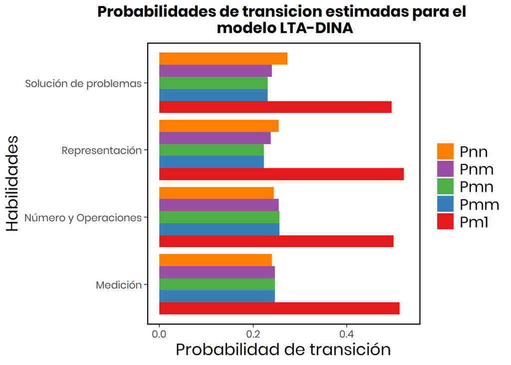

```r
# Transition plot
trans_plot <- ggplot(data = tbl_trans_plot, aes(x = Habilidades, y = p_trans,
                                  fill = p_trans1)) +
  geom_bar(stat = 'identity', position = 'dodge') +
  scale_fill_manual(labels = c("Pm1","Pmm","Pmn","Pnm","Pnn"),
                    values = RColorBrewer::brewer.pal(5, "Set1")) +
  custom_theme +
  theme(legend.position = 'right', legend.title = element_blank(),
        axis.text = element_text(size = 10)) +
  guides(fill = guide_legend(reverse = TRUE)) +
  labs(y = 'Probabilidad de transición',
       title="Probabilidades de transicion estimadas para el \n modelo LTA-DINA") +
  coord_flip() +
  scale_y_continuous(limits = c(0, .53))

# Export function of transition plot
ggsave(filename = "../Imagenes/Probabilidades_transicion.pdf",
       plot = trans_plot, device = "pdf", width = 6, height = 5)
```

Ya por ultimo, se grafica la matriz de transicion y se exporta con `ggsave()`.